# Analyzing The Effects Of Severe Weather Events On Population Health and Economy In the US

vyndk

August 28, 2018

## Synopsis

The goal of the analysis is answering two following questions:

1. Across the United States, which types of events (as indicated in the EVTYPE variable) are most harmful with respect to population health?
2. Across the United States, which types of events have the greatest economic consequences?

The data used for this analysis is the U.S. National Oceanic and Atmospheric Administration’s (NOAA) storm database which tracks characteristics of major storms and weather events in the United States, including when and where they occur, as well as estimates of any fatalities, injuries, and property damage from 1950 to November 2011.

The dataset is downloaded from https://d396qusza40orc.cloudfront.net/repdata%2Fdata%2FStormData.csv.bz2 in 2018-28-08. The document for the dataset is downloaded from https://d396qusza40orc.cloudfront.net/repdata%2Fpeer2_doc%2Fpd01016005curr.pdf in 2018-28-8

## Prerequisite Packages

Load necessary packages

```r
library(tidyverse)
```

## Read and summary data

Read data

```r
fileName <- "StormData.csv.bz2"
data <- read_csv(file = fileName, col_names = TRUE)
```

view some pieces of data

```r
head(data)
```

```
## # A tibble: 6 x 37
##   STATE__ BGN_DATE BGN_TIME TIME_ZONE COUNTY COUNTYNAME STATE EVTYPE
##     <dbl> <chr>    <chr>    <chr>      <dbl> <chr>      <chr> <chr>
## 1       1 4/18/19… 0130     CST           97 MOBILE     AL    TORNA…
## 2       1 4/18/19… 0145     CST            3 BALDWIN    AL    TORNA…
## 3       1 2/20/19… 1600     CST           57 FAYETTE    AL    TORNA…
## 4       1 6/8/195… 0900     CST           89 MADISON    AL    TORNA…
## 5       1 11/15/1… 1500     CST           43 CULLMAN    AL    TORNA…
## 6       1 11/15/1… 2000     CST           77 LAUDERDALE AL    TORNA…
## # ... with 29 more variables: BGN_RANGE <dbl>, BGN_AZI <chr>,
## #   BGN_LOCATI <chr>, END_DATE <chr>, END_TIME <chr>, COUNTY_END <dbl>,
## #   COUNTYENDN <chr>, END_RANGE <dbl>, END_AZI <chr>, END_LOCATI <chr>,
## #   LENGTH <dbl>, WIDTH <dbl>, F <int>, MAG <dbl>, FATALITIES <dbl>,
## #   INJURIES <dbl>, PROPDMG <dbl>, PROPDMGEXP <chr>, CROPDMG <dbl>,
## #   CROPDMGEXP <chr>, WFO <chr>, STATEOFFIC <chr>, ZONENAMES <chr>,
## #   LATITUDE <dbl>, LONGITUDE <dbl>, LATITUDE_E <dbl>, LONGITUDE_ <dbl>,
## #   REMARKS <chr>, REFNUM <dbl>
```

## Data Processing

1. Select the necessary columns To answer the questions we only need the following columns:
- EVTYPE - Event Type
- FATALITIES - Number of reported fatalities caused by the event.
- INJURIES - Number of reported injuries caused by the event.
- PROPDMG - The dollar (USD) amount of property damage caused by the event.
- PROPDMGEXP - The exponential for the dollar (USD) amount of property damage caused by the event.
- CROPDMG - The dollar (USD) amount of crop damage caused by the event.
- CROPDMGEXP - The exponential for the dollar (USD) amount of crop damage caused by the event. So we select these columns and drop the others

```r
col_names <- c("EVTYPE", "FATALITIES", "INJURIES", "PROPDMG", "PROPDMGEXP", "CROPDMG", "CROPDMGEXP")
need_data <- data %>% select(col_names)
head(need_data)
```

```
## # A tibble: 6 x 7
##   EVTYPE  FATALITIES INJURIES PROPDMG PROPDMGEXP CROPDMG CROPDMGEXP
##   <chr>        <dbl>    <dbl>   <dbl> <chr>        <dbl> <chr>
## 1 TORNADO          0       15    25   K                0 <NA>
## 2 TORNADO          0        0     2.5 K                0 <NA>
## 3 TORNADO          0        2    25   K                0 <NA>
## 4 TORNADO          0        2     2.5 K                0 <NA>
## 5 TORNADO          0        2     2.5 K                0 <NA>
## 6 TORNADO          0        6     2.5 K                0 <NA>
```

2. Standardize the event name Find the total unique value of events.

```r
length(unique(need_data$EVTYPE))
```

```
## [1] 977
```

We can see that there are too much value compared to EVTYPE’s listed in the document of the dataset. So we need to clean and sandardize the event type name

```r
# list valid event name
valid_event_name = c("Tide",
                    "Avalanche",
                    "Blizzard",
                    "Flood",
                    "Chill",
                    "Debris Flow",
                    "Fog",
                    "Smoke",
                    "Drought",
                    "Dust",
                    "Heat",
                    "Frost/Freeze",
                    "Cloud",
                    "Hail",
                    "Rain",
                    "Snow",
                    "Surf",
                    "Wind",
                    "Hurricane",
                    "Ice",
                    "Lightning",
                    "Current",
                    "Seiche",
                    "Sleet",
                    "Surge",
                    "Thunderstorm",
                    "Tornado",
                    "Depression",
                    "Tsunami",
                    "Volcanic Ash",
                    "Waterspout",
                    "Wildfire",
                    "Storm",
                    "Winter" )
# Define the funtion return the valid name of a event or NA
get_name <- function(name){
    name <- tolower(name)
    name <- sub("\\\\", " ", name) # eliminate \'s
    name <- sub("-", " ", name) # eliminate -'s
    name <- sub("/", " ", name) # eliminate /'s
    name <- gsub("\\s+", " ", name) # compress multiple spaces
    name <- trimws(name) # trim leading and trailing whitespace
    for(sd in valid_event_name){
        l1 <- unlist(strsplit(tolower(sd), " "))
        l2 <- unlist(strsplit(name, " "))
        for(s in l2){
            if(s %in% l1){
                return(sd)
            }
        }
    }
    NA
}

# standardize the event name and choose those which are not
need_data$EVTYPE <- sapply(need_data$EVTYPE, get_name)
```

Filter out all invalid event name

```r
need_data <- need_data %>% filter(!is.na(EVTYPE))
need_data
```

```
## # A tibble: 888,938 x 7
##    EVTYPE  FATALITIES INJURIES PROPDMG PROPDMGEXP CROPDMG CROPDMGEXP
##    <chr>        <dbl>    <dbl>   <dbl> <chr>        <dbl> <chr>
##  1 Tornado          0       15    25   K                0 <NA>
##  2 Tornado          0        0     2.5 K                0 <NA>
##  3 Tornado          0        2    25   K                0 <NA>
##  4 Tornado          0        2     2.5 K                0 <NA>
##  5 Tornado          0        2     2.5 K                0 <NA>
##  6 Tornado          0        6     2.5 K                0 <NA>
##  7 Tornado          0        1     2.5 K                0 <NA>
##  8 Tornado          0        0     2.5 K                0 <NA>
##  9 Tornado          1       14    25   K                0 <NA>
## 10 Tornado          0        0    25   K                0 <NA>
## # ... with 888,928 more rows
```

3. Process the damage amount

The property damage amount and the crop damage amount are stored in two pair of columns. “PROPDMG” store the amount of property damage and “PROPDMGEXP” store it exponential. “CROPDMG” store the amount of crop damage and “CROPDMGEXP” store it exponential

We need to merge each pair columms and create 2 new column PROPDMG.NEW = PROPDMG * 10^PROPDMGEXP CROPDMG.NEW = CROPDMG * 10^CROPDMGEXP

View the list unique value of PROPDMGEXP and CROPDMGEXP

```r
unique(need_data$PROPDMGEXP)
```

```
##  [1] "K" "M" NA  "B" "m" "+" "0" "5" "6" "?" "4" "2" "3" "h" "7" "H" "-"
## [18] "1" "8"
```

```r
unique(need_data$CROPDMGEXP)
```

```
## [1] NA  "M" "K" "m" "B" "?" "0" "k" "2"
```

From these value we convert the exponential columns to right value

```r
get_expo <- function(x){
    if(is.na(x)){
        return(1)
    }
    x <- toupper(x)
    if(x == "+" || x == "?" || x == "-"){
        1
    }else if(x == "K"){
        3
    }else if(x == "M"){
        6
    }else if(x == "B"){
        9
    }else if(x == "H"){
        2
    }else{
        strtoi(x)
    }
}
need_data$PROPDMGEXP <- sapply(need_data$PROPDMGEXP, get_expo)
need_data$CROPDMGEXP <- sapply(need_data$CROPDMGEXP, get_expo)

need_data <- need_data %>% mutate(PROPDMG.NEW = PROPDMG * 10^PROPDMGEXP, CROPDMG.NEW = CROPDMG * 10^CROPDMGEXP)
need_data
```

```
## # A tibble: 888,938 x 9
##    EVTYPE FATALITIES INJURIES PROPDMG PROPDMGEXP CROPDMG CROPDMGEXP
##    <chr>       <dbl>    <dbl>   <dbl>      <dbl>   <dbl>      <dbl>
##  1 Torna…          0       15    25            3       0          1
##  2 Torna…          0        0     2.5          3       0          1
##  3 Torna…          0        2    25            3       0          1
##  4 Torna…          0        2     2.5          3       0          1
##  5 Torna…          0        2     2.5          3       0          1
##  6 Torna…          0        6     2.5          3       0          1
##  7 Torna…          0        1     2.5          3       0          1
##  8 Torna…          0        0     2.5          3       0          1
##  9 Torna…          1       14    25            3       0          1
## 10 Torna…          0        0    25            3       0          1
## # ... with 888,928 more rows, and 2 more variables: PROPDMG.NEW <dbl>,
## #   CROPDMG.NEW <dbl>
```

## Result

### Find the top Event that cause the most damage on public health

The new column HEALTH.DAMAGE = FATALITIES + INJURIES is created. Then we sum HEALTH.DAMAGE for each event. Because there are many event, we only care 5 top event which cause the most damage

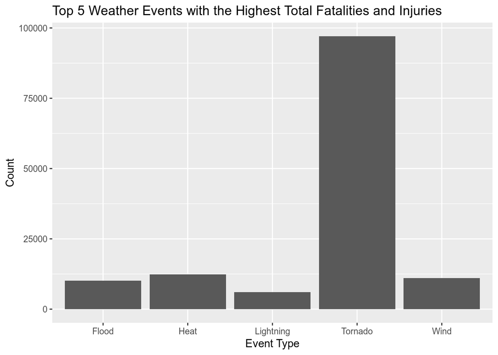

```r
# summarise data
health_damage <- need_data %>% mutate(HEALTH.DAMAGE = FATALITIES + INJURIES)
health_damage <- health_damage %>% group_by(EVTYPE) %>% summarise(HEALTH.TOTAL.DAMAGE = sum(HEALTH.DAMAGE))
# get 5 top event with the Highest Total Fatalities and Injuries
top_health_damage <-head(health_damage[order(health_damage$HEALTH.TOTAL.DAMAGE, decreasing = TRUE), ], n = 5)
#plot
ggplot(data=top_health_damage, aes(x=EVTYPE, y=HEALTH.TOTAL.DAMAGE)) +
    geom_bar(stat="identity") +
    ggtitle(label = "Top 5 Weather Events with the Highest Total Fatalities and Injuries") +
    labs(x = "Event Type", y = "Count")
```

We can see that Tornado cause the the highest total fatalities and injuries

### Find the top Event that cause the most damage on economy

The new column ECO.DAMAGE = CROPDMG.NEW + CROPDMG.NEW is created. Then we sum ECO.DAMAGE for each event. Because there are many event, we only care 5 top event which cause the most damage

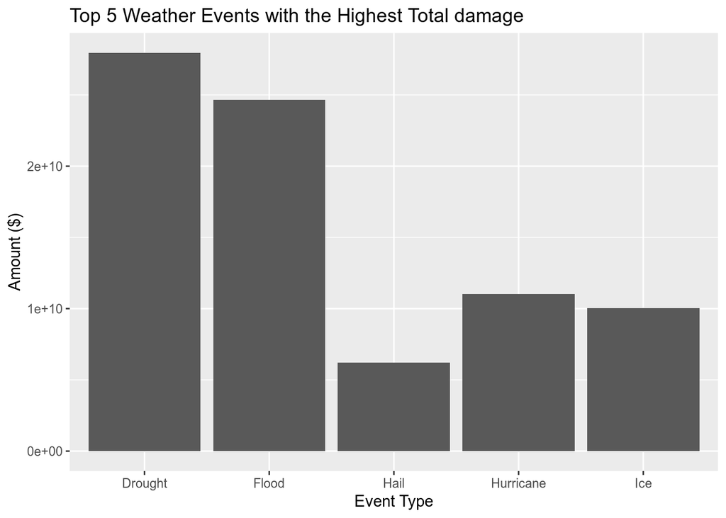

```r
# summarise data
eco_damage <- need_data %>% mutate(ECO.DAMAGE = CROPDMG.NEW + CROPDMG.NEW)
eco_damage <- eco_damage %>% group_by(EVTYPE) %>% summarise(ECO.TOTAL.DAMAGE = sum(ECO.DAMAGE))
# get 5 top event with the Highest Total damage on property and crop
top_eco_damage <-head(eco_damage[order(eco_damage$ECO.TOTAL.DAMAGE, decreasing = TRUE), ], n = 5)
#plot
ggplot(data=top_eco_damage, aes(x=EVTYPE, y=ECO.TOTAL.DAMAGE)) +
    geom_bar(stat="identity") +
    ggtitle(label = "Top 5 Weather Events with the Highest Total damage") +
    labs(x = "Event Type", y = "Amount ($)")
```